# SCM

A new article created using the Distill format.

SangDon Kim  
2022-05-07

```r
library(dagitty)
library(tidyverse)
library(psychTools)
library(bnlearn)
library(skimr)
```

## Potential outcome

$$\text{Causal effect of treatment} = \text{처치 그룹 하에서 처치를 받았을
때의 결과} - \text{처치그룹 하에서 처치를 받지 않았다면 얻을 잠재적
결과(counterfactual)}$$
- 즉, 처치 그룹의 실제결과와 잠재적 결과 간의 차이를 비교분석

- 현실에서는 counterfactual을 관찰할 수 없음
- 대안 : 통제그룹을 두고 처리그룹과 통제그룹(처리를 받지 않은 그룹)을 비교

counterfactual과 통제 그룹 간의 차이를 좁히는 것이 인과추론의 정확도를 결정하는 핵심 요소로 볼 수 있음$\text{(처치 그룹에서 처치가 없을 대의 결과)} \approx \text{(처치를 받지 않은 통제 그룹에서의 결과)}$

### Selection bias

$$\begin{align}
\text{Selection bias} &= \text{처치를 받은 처치 그룹의 결과} -
\text{처치를 받지 않은 통제 그룹의 결과} \\
&= (\text{처치를 받은 처치 그룹의 결과} - \text{처치를 받지 않은
처치 그룹의 결과})+(\text{처치를 받지 않은 처치 그룹의 결과} -
\text{처치를 받지 않은 통제 그룹의 결과}) \\
&=\text{Causal effect} + \text{Selection bias}
\end{align}$$

Selection bias를 줄이기 위해서는 counterfactual과 가까운 통제 그룹을 찾을 수 있는 연구 디자인을 고안해야 함

# causal diagram

변수 간의 상관관계를 도식화하여 쉽게 이해하기 위해서 사용함

# Graph 용어 정리

- 노드의 위치를 [pos = “”]로 정할 수 있음
- 왼쪽 상단이 (0, 0)에 해당함

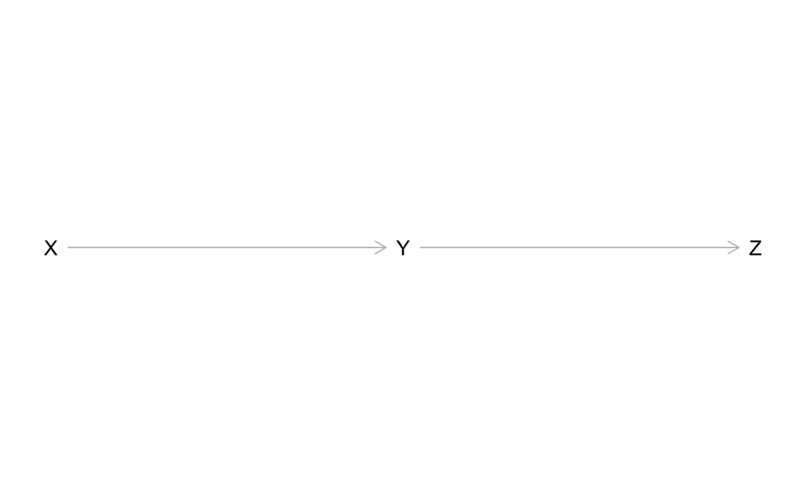

```r
g <- dagitty('dag {
    X [pos="0,1"]
    Y [pos="1,1"]
    Z [pos="2,1"]

    X -> Y -> Z
}')

plot(g)
```

- $X$는 $Y$의 parent
- $Y$는 $X$의 child
- 두 개의 엣지가 향하는 방향이 같은 경우이므로 direct path에 해당
- $X$는 $Y$, $Z$의 ancestor
- $Y$, $Z$는 $X$의 descentant
- 화살표가 있으므로 directed path(없을 경우 undirected path)

## Example

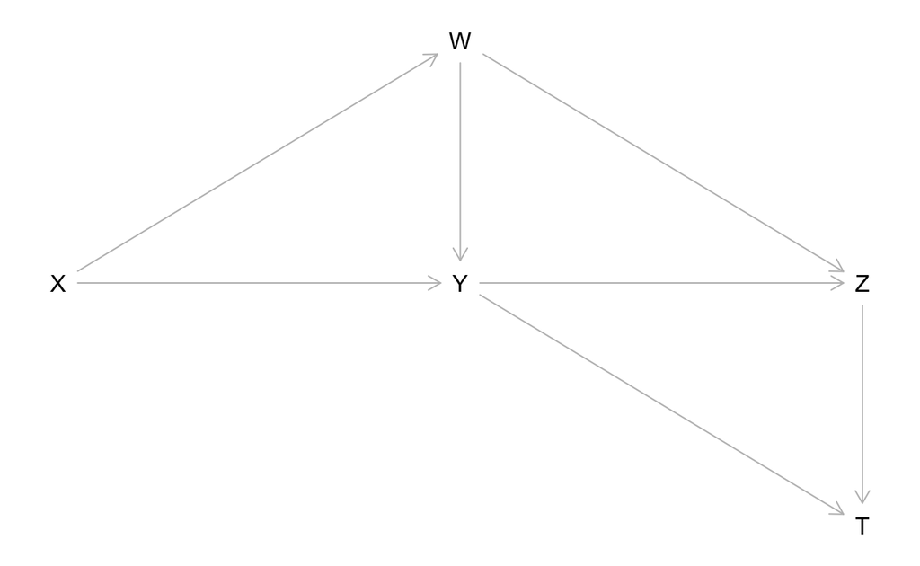

```r
g <- dagitty('dag {
    X [pos="0,1"]
    Y [pos="1,1"]
    Z [pos="2,1"]
    W [pos="1,0"]
    T [pos="2,2"]

    X -> Y -> Z -> T
    X -> W -> Y -> T
    W -> Z
}')
plot(g)
```

```r
dagitty::parents(g, "Z")
```

```
[1] "W" "Y"
```

```r
dagitty::ancestors(g, "Z")
```

```
[1] "Z" "Y" "X" "W"
```

```r
dagitty::children(g, "W")
```

```
[1] "Y" "Z"
```

```r
dagitty::descendants(g, "W")
```

```
[1] "W" "Z" "T" "Y"
```

# Graph 종류

## Chain(사슬)

- $X \not\!\perp\!\!\!\perp Z$
- $X \perp\!\!\!\perp Z | Y$
- 불면증($X$)는 피로($Y$)의 원인이 되고, 집중력($Z$)의 원인이 됨

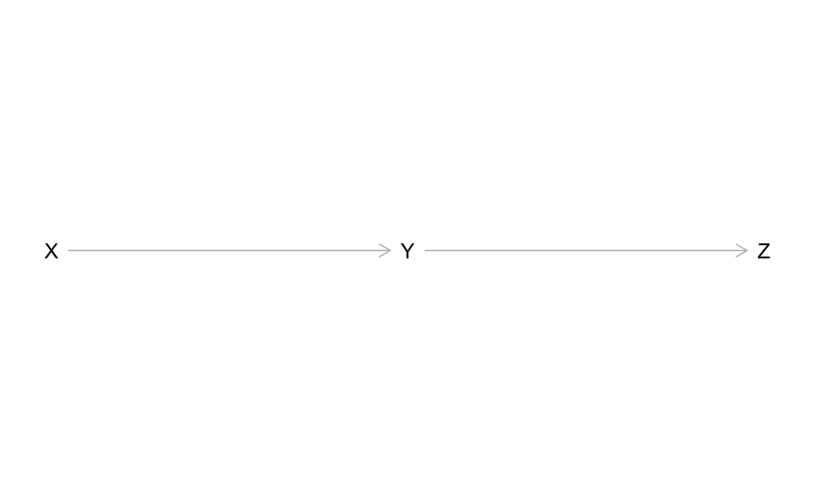

```r
g <- dagitty('dag {
    X [pos="0,1"]
    Y [pos="1,1"]
    Z [pos="2,1"]

    X -> Y -> Z
}')

plot(g)
```

## Fork(Common cause, 분기)

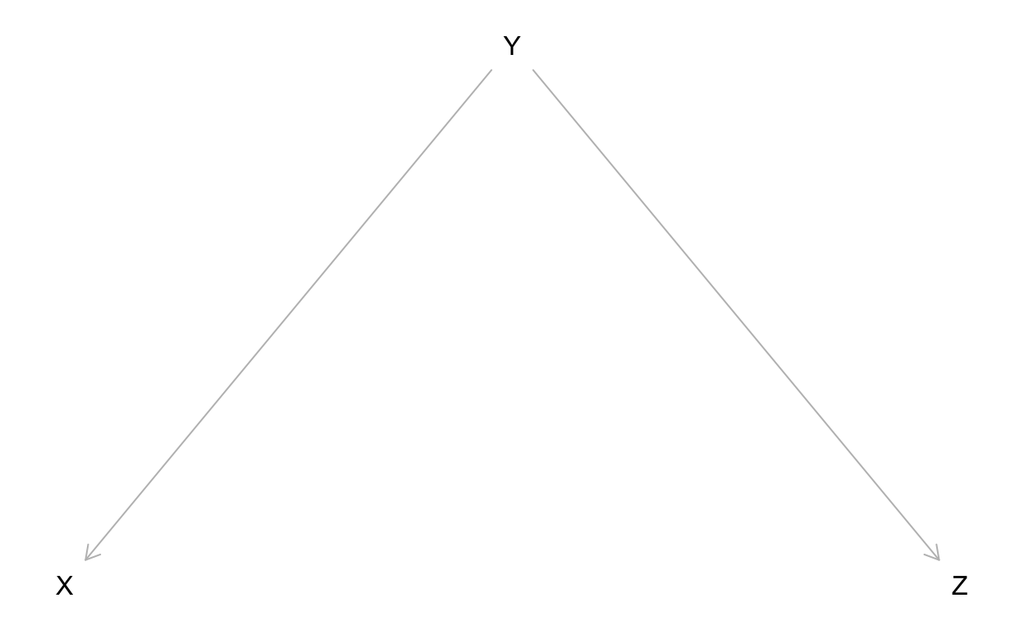

```r
g <- dagitty('dag {
    X [pos="0,1"]
    Y [pos="1,0"]
    Z [pos="2,1"]

    Y -> X
    Y -> Z
}')

plot(g)
```

## Collider(or immorality, 충돌부)

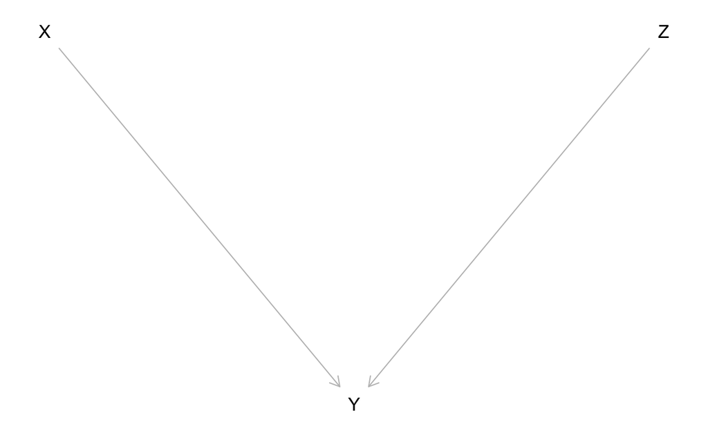

```r
g <- dagitty('dag {
    X [pos="0,0"]
    Y [pos="1,1"]
    Z [pos="2,0"]

    X -> Y
    Z -> Y
}')

plot(g)
```

- $X \perp\!\!\!\perp Z$
- $X \not\!\perp\!\!\!\perp Z | Y$
- 학급의 수준($X$)과 학생들의 지능($Z$)은 성적($Y$)의 원인이 됨

# $d$-seperated($d$ 분리)

# R package

- bnlearn
- pcalg

# tutorial

## Data description

25가지 성격 자기 보고 항목, 인구통계학 변수(성별, 교육, 연령)

```r
data('bfi')
skim(bfi)
```

Table 1: Data summary

| Name | bfi |
| --- | --- |
| Number of rows | 2800 |
| Number of columns | 28 |
| _______________________ |  |
| Column type frequency: |  |
| numeric | 28 |
| ________________________ |  |
| Group variables | None |

**Variable type: numeric**

| skim_variable | n_missing | complete_rate | mean | sd | p0 | p25 | p50 | p75 | p100 | hist |
| --- | --- | --- | --- | --- | --- | --- | --- | --- | --- | --- |
| A1 | 16 | 0.99 | 2.41 | 1.41 | 1 | 1 | 2 | 3 | 6 | ▇▂▂▁▁ |
| A2 | 27 | 0.99 | 4.80 | 1.17 | 1 | 4 | 5 | 6 | 6 | ▂▁▅▇▇ |
| A3 | 26 | 0.99 | 4.60 | 1.30 | 1 | 4 | 5 | 6 | 6 | ▂▂▅▇▆ |
| A4 | 19 | 0.99 | 4.70 | 1.48 | 1 | 4 | 5 | 6 | 6 | ▂▁▃▅▇ |
| A5 | 16 | 0.99 | 4.56 | 1.26 | 1 | 4 | 5 | 5 | 6 | ▂▂▅▇▆ |
| C1 | 21 | 0.99 | 4.50 | 1.24 | 1 | 4 | 5 | 5 | 6 | ▂▂▅▇▅ |
| C2 | 24 | 0.99 | 4.37 | 1.32 | 1 | 4 | 5 | 5 | 6 | ▃▂▆▇▅ |
| C3 | 20 | 0.99 | 4.30 | 1.29 | 1 | 4 | 5 | 5 | 6 | ▃▂▆▇▅ |
| C4 | 26 | 0.99 | 2.55 | 1.38 | 1 | 1 | 2 | 4 | 6 | ▇▂▂▁▁ |
| C5 | 16 | 0.99 | 3.30 | 1.63 | 1 | 2 | 3 | 5 | 6 | ▇▂▅▃▂ |
| E1 | 23 | 0.99 | 2.97 | 1.63 | 1 | 2 | 3 | 4 | 6 | ▇▂▃▂▂ |
| E2 | 16 | 0.99 | 3.14 | 1.61 | 1 | 2 | 3 | 4 | 6 | ▇▂▃▂▂ |
| E3 | 25 | 0.99 | 4.00 | 1.35 | 1 | 3 | 4 | 5 | 6 | ▅▃▇▇▃ |
| E4 | 9 | 1.00 | 4.42 | 1.46 | 1 | 4 | 5 | 6 | 6 | ▃▂▃▇▆ |
| E5 | 21 | 0.99 | 4.42 | 1.33 | 1 | 4 | 5 | 5 | 6 | ▃▂▅▇▅ |
| N1 | 22 | 0.99 | 2.93 | 1.57 | 1 | 2 | 3 | 4 | 6 | ▇▂▃▂▁ |
| N2 | 21 | 0.99 | 3.51 | 1.53 | 1 | 2 | 4 | 5 | 6 | ▇▃▆▅▃ |
| N3 | 11 | 1.00 | 3.22 | 1.60 | 1 | 2 | 3 | 4 | 6 | ▇▂▅▃▂ |
| N4 | 36 | 0.99 | 3.19 | 1.57 | 1 | 2 | 3 | 4 | 6 | ▇▃▅▃▂ |
| N5 | 29 | 0.99 | 2.97 | 1.62 | 1 | 2 | 3 | 4 | 6 | ▇▂▃▂▂ |
| O1 | 22 | 0.99 | 4.82 | 1.13 | 1 | 4 | 5 | 6 | 6 | ▁▂▅▇▇ |
| O2 | 0 | 1.00 | 2.71 | 1.57 | 1 | 1 | 2 | 4 | 6 | ▇▂▂▂▁ |
| O3 | 28 | 0.99 | 4.44 | 1.22 | 1 | 4 | 5 | 5 | 6 | ▂▂▆▇▅ |
| O4 | 14 | 1.00 | 4.89 | 1.22 | 1 | 4 | 5 | 6 | 6 | ▁▁▃▆▇ |
| O5 | 20 | 0.99 | 2.49 | 1.33 | 1 | 1 | 2 | 3 | 6 | ▇▂▂▁▁ |
| gender | 0 | 1.00 | 1.67 | 0.47 | 1 | 1 | 2 | 2 | 2 | ▃▁▁▁▇ |
| education | 223 | 0.92 | 3.19 | 1.11 | 1 | 3 | 3 | 4 | 5 | ▂▂▇▂▃ |
| age | 0 | 1.00 | 28.78 | 11.13 | 3 | 20 | 26 | 35 | 86 | ▃▇▂▁▁ |

```r
bfi %>% str()
```

```
'data.frame':   2800 obs. of  28 variables:
 $ A1       : int  2 2 5 4 2 6 2 4 4 2 ...
 $ A2       : int  4 4 4 4 3 6 5 3 3 5 ...
 $ A3       : int  3 5 5 6 3 5 5 1 6 6 ...
 $ A4       : int  4 2 4 5 4 6 3 5 3 6 ...
 $ A5       : int  4 5 4 5 5 5 5 1 3 5 ...
 $ C1       : int  2 5 4 4 4 6 5 3 6 6 ...
 $ C2       : int  3 4 5 4 4 6 4 2 6 5 ...
 $ C3       : int  3 4 4 3 5 6 4 4 3 6 ...
 $ C4       : int  4 3 2 5 3 1 2 2 4 2 ...
 $ C5       : int  4 4 5 5 2 3 3 4 5 1 ...
 $ E1       : int  3 1 2 5 2 2 4 3 5 2 ...
 $ E2       : int  3 1 4 3 2 1 3 6 3 2 ...
 $ E3       : int  3 6 4 4 5 6 4 4 NA 4 ...
 $ E4       : int  4 4 4 4 4 5 5 2 4 5 ...
 $ E5       : int  4 3 5 4 5 6 5 1 3 5 ...
 $ N1       : int  3 3 4 2 2 3 1 6 5 5 ...
 $ N2       : int  4 3 5 5 3 5 2 3 5 5 ...
 $ N3       : int  2 3 4 2 4 2 2 2 2 5 ...
 $ N4       : int  2 5 2 4 4 2 1 6 3 2 ...
 $ N5       : int  3 5 3 1 3 3 1 4 3 4 ...
 $ O1       : int  3 4 4 3 3 4 5 3 6 5 ...
 $ O2       : int  6 2 2 3 3 3 2 2 6 1 ...
 $ O3       : int  3 4 5 4 4 5 5 4 6 5 ...
 $ O4       : int  4 3 5 3 3 6 6 5 6 5 ...
 $ O5       : int  3 3 2 5 3 1 1 3 1 2 ...
 $ gender   : int  1 2 2 2 1 2 1 1 1 2 ...
 $ education: int  NA NA NA NA NA 3 NA 2 1 NA ...
 $ age      : int  16 18 17 17 17 21 18 19 19 17 ...
```

```r
bfi <- janitor::clean_names(bfi)
```

```r
bfiNoNA <- na.omit(bfi)
```

```r
bfiNoNA <- bfiNoNA %>%
    mutate(gender = factor(gender, levels = c(1, 2), labels = c("Male", "Female"))) %>%
    mutate_if(is.integer, as.numeric)
# bfiNoNA %>% str()
```

```r
bfisub <- bfiNoNA %>%
    select(age, education, c5, o1, n5)
```

```r
Whitelist <- matrix(c("age", "education"),, 2, byrow = T)

colnames(Whitelist) <- c("from", "to")
```

```r
Blacklist <- matrix(c("education", "age",
                      "c5", "age",
                      "o1", "age",
                      "n5", "age"), , 2, byrow = T)
colnames(Blacklist) <- c("from", "to")
Blacklist
```

```
     from        to
[1,] "education" "age"
[2,] "c5"        "age"
[3,] "o1"        "age"
[4,] "n5"        "age"
```

## estimation

```r
res <- bnlearn::iamb(bfisub, whitelist = Whitelist, blacklist = Blacklist)
res
```

```
  Bayesian network learned via Constraint-based methods

  model:
    [partially directed graph]
  nodes:                                 5
  arcs:                                  6
    undirected arcs:                     1
    directed arcs:                       5
  average markov blanket size:           2.40
  average neighbourhood size:            2.40
  average branching factor:              1.00

  learning algorithm:                    IAMB
  conditional independence test:         Pearson's Correlation
  alpha threshold:                       0.05
  tests used in the learning procedure:  98
```

## visualization

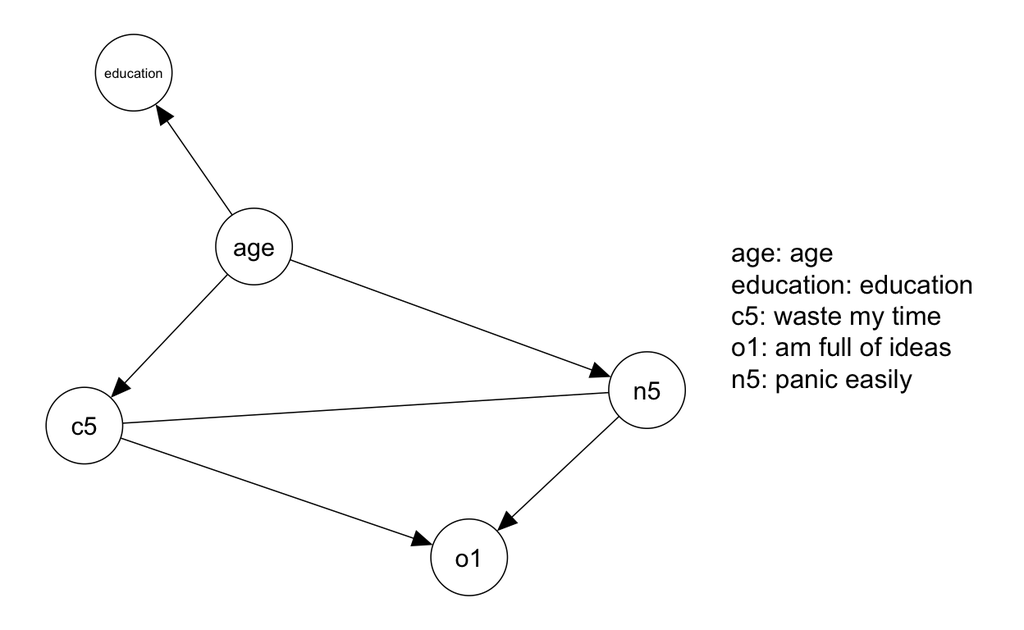

```r
labels <- c("age", "education", "waste my time", "am full of ideas", "panic easily")
library(qgraph)

qgraph(res, nodeNames = labels, legend.cex = 0.5, asize = 5, edge.color = "black")
```

## parameterization

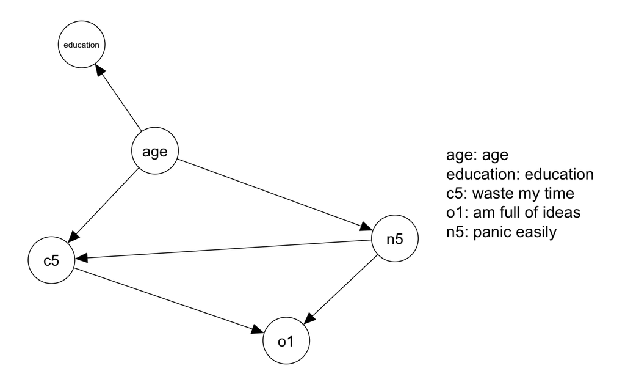

```r
res <- set.arc(res, from = "n5", to = "c5")

g <- qgraph(res, nodeNames = labels, legend.cex = 0.5, asize = 5, edge.color = "black")
```

```r
g
```

```
From        To  Weight
1    -->     2   1
1    -->     3   1
1    -->     5   1
3    -->     4   1
5    -->     3   1
5    -->     4   1
```

## fitting

```r
fit <- bn.fit(res, bfisub)
fit$education
```

```
  Parameters of node education (Gaussian distribution)

Conditional density: education | age
Coefficients:
(Intercept)          age
 2.42507442   0.02596853
Standard deviation of the residuals: 1.076872
```

```r
fit$c5
```

```
  Parameters of node c5 (Gaussian distribution)

Conditional density: c5 | age + n5
Coefficients:
 (Intercept)           age            n5
 2.974358446  -0.008372146   0.178877531
Standard deviation of the residuals: 1.600155
```

## boostrapping

```r
boot <- boot.strength(bfisub, R = 1000, algorithm = "iamb",
                      algorithm.args = list(whitelist = Whitelist,
                                            blacklist = Blacklist))
```

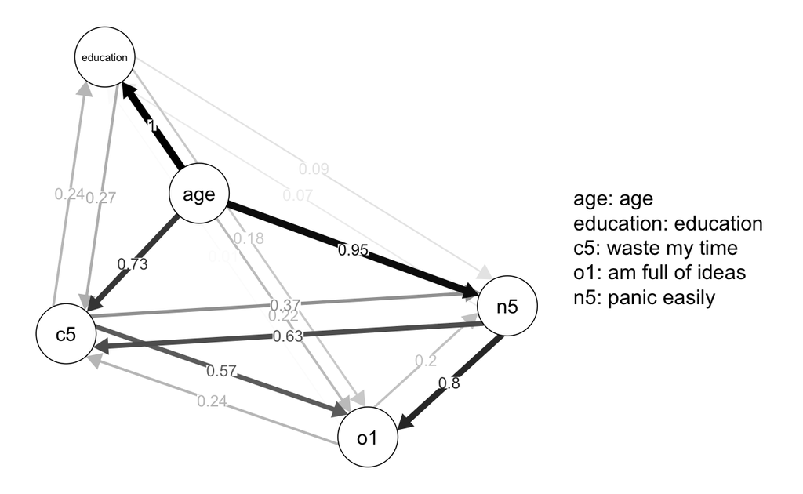

```r
qgraph(boot, nodeNames = labels, legend.cex = 0.5, edge.labels = T, layout = g$layout,
       asize = 5, edge.color = "black")
```

# covid example

https://osf.io/vzawg/